# Plant-Seedlings-Image-Classification

## Project - Image classification using CNNs in Keras

### Problem statement

A dataset of images of plant seedlings at various stages of growth is provided. Each image has a filename that is its unique id. The dataset comprises 12 plant species. The goal of the projectis to create a classifier capable of determining a plant's species from a photo.

#### Objective

To implement the techniques learnt as a part of the course.

##### Learning Outcomes:

- Pre-processing of image data.
- Visualization of images.
- Building CNN.
- Evaluate the Model.
- The motive of the project is to make the learners capable to handle images/image classification problems, during this process you shouldalso be capable to handle real image files, not just limited to a numpy array of image pixels

#### Context

Can you differentiate a weed from a crop seedling? The ability to do so effectively can mean better crop yields and better stewardship of the environment.The Aarhus University Signal Processing group, in collaboration with University of Southern Denmark, has recently released a dataset containing images of unique plants belonging to 12 species at several growth stage

#### Dataset:

The dataset can be download from Olympus. The data file names are:

- images.npy
- Label.csv

The original files are from Kaggle.Due to the large volume of data, the images were converted to images.npy file and the labels are also put into the Labels.csv.

#### 1. Import the necessary packages

```python
# Load Libraries
import numpy as np
import pandas as pd
import os as os

# Image processing
import matplotlib.pyplot as plt
import seaborn as sns
from PIL import Image
from array import array
import cv2 as cv2

import imageio
import skimage
import skimage.io
import skimage.transform
from imageio import imread


from keras.preprocessing.image import ImageDataGenerator, array_to_img, img_to_array, load_img
from keras.models import Sequential
from keras.layers.normalization import BatchNormalization
from keras.layers.convolutional import Conv2D
from keras.layers.convolutional import MaxPooling2D
from keras.layers.core import Activation
from keras.layers.core import Flatten
from keras.layers.core import Dropout
from keras.layers.core import Dense
from keras.layers.normalization import BatchNormalization
from keras.callbacks import ModelCheckpoint, Callback, EarlyStopping, ReduceLROnPlateau
```

```python
import warnings
warnings.filterwarnings('ignore')
```

### Loading the data

```python
# Check number of images in each label

train_images = np.load('images.npy')
labels = pd.read_csv('Labels.csv')
print("Training Images shape: ", train_images.shape)
print("Training Labels shape: ", labels.shape)
```

```
Training Images shape:  (4750, 128, 128, 3)
Training Labels shape:  (4750, 1)
```

```python
print(train_images[0])
```

[output not shown]

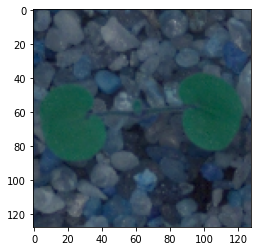

```python
plt.imshow(train_images[0])
```

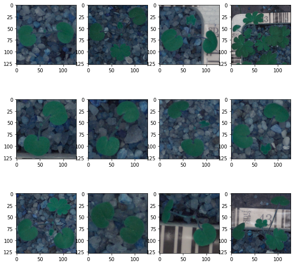

```python
# Display some sample images

plt.figure(figsize=(10,10))
for i in range(12):
    plt.subplot(3, 4, i + 1)
    plt.imshow(train_images[i])
```

```python
train_labels = pd.DataFrame(labels)
train_labels
```

|  | Label |
| --- | --- |
| 0 | Small-flowered Cranesbill |
| 1 | Small-flowered Cranesbill |
| 2 | Small-flowered Cranesbill |
| 3 | Small-flowered Cranesbill |
| 4 | Small-flowered Cranesbill |
| ... | ... |
| 4745 | Loose Silky-bent |
| 4746 | Loose Silky-bent |
| 4747 | Loose Silky-bent |
| 4748 | Loose Silky-bent |
| 4749 | Loose Silky-bent |

4750 rows × 1 columns

#### Distribution of images

```python
train_labels.value_counts()
```

```
Label
Loose Silky-bent             654
Common Chickweed             611
Scentless Mayweed            516
Small-flowered Cranesbill    496
Fat Hen                      475
Charlock                     390
Sugar beet                   385
Cleavers                     287
Black-grass                  263
Shepherds Purse              231
Maize                        221
Common wheat                 221
dtype: int64
```

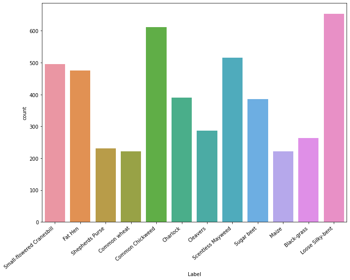

```python
plt.figure(figsize=(10,8))
ax = sns.countplot(x ='Label', data = train_labels)
ax.set_xticklabels(ax.get_xticklabels(), rotation=40, ha="right")
plt.tight_layout()
plt.show()
```

From the above plot, we can see that all the plant species do not have the same count or number of images and the data set is unbalanced.

### Data Pre-Processing

#### Apply image processing on the images

- Normalization
- Gaussian Blurring

```python
clear_train_imgs = []
```

```python
# Now we apply the gaussian blur to each image to reduce the noise in the image

for img in train_images:
        blur_img = cv2.GaussianBlur(img, (5, 5), 0)
        clear_train_imgs.append(blur_img)
```

```python
clear_train_imgs = np.asarray(clear_train_imgs)
```

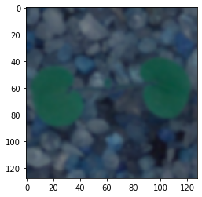

```python
plt.imshow(clear_train_imgs[0])
```

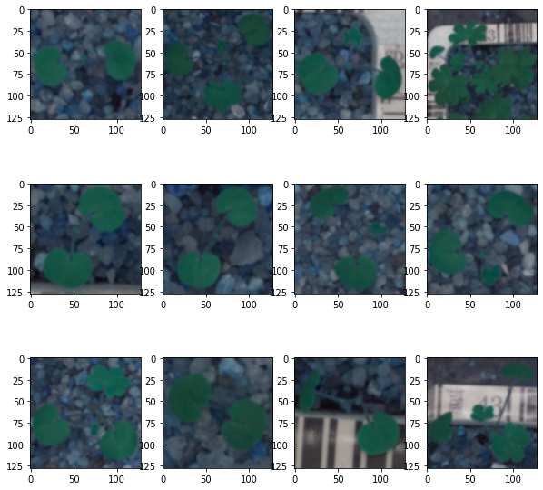

```python
# Display altered sample images

plt.figure(figsize=(10,10))
for i in range(12):
    plt.subplot(3,4,i+1)
    plt.imshow(clear_train_imgs[i])  # Blur image
```

```python
# Normalize the training data

clear_train_imgs = clear_train_imgs/255
```

### Label Encoding

```python
from sklearn.preprocessing import LabelBinarizer

enc = LabelBinarizer()
y = enc.fit_transform(labels)
```

```python
enc.classes_
```

```
array(['Black-grass', 'Charlock', 'Cleavers', 'Common Chickweed',
       'Common wheat', 'Fat Hen', 'Loose Silky-bent', 'Maize',
       'Scentless Mayweed', 'Shepherds Purse',
       'Small-flowered Cranesbill', 'Sugar beet'], dtype='<U25')
```

```python
y.shape
```

```
(4750, 12)
```

```python
y[0]
```

```
array([0, 0, 0, 0, 0, 0, 0, 0, 0, 0, 1, 0])
```

### Split Data into training and test sets

```python
from sklearn.model_selection import train_test_split

X_train, X_test, y_train, y_test = train_test_split(clear_train_imgs, y, test_size=0.3, random_state=50)
```

```python
X_train.shape
```

```
(3325, 128, 128, 3)
```

### Split data further to create a validation set

```python
random_seed = 100
X_test, X_val, y_test, Y_val = train_test_split(X_test,y_test, test_size = 0.5, random_state=random_seed)
```

```python
print(X_test.shape)
print(X_val.shape)
```

```
(712, 128, 128, 3)
(713, 128, 128, 3)
```

## Building a CNN Model

```python
from keras.models import Sequential
from keras.layers import Dense, Dropout, Flatten, Conv2D, MaxPool2D, GlobalMaxPooling2D
from keras.optimizers import RMSprop
from keras.preprocessing.image import ImageDataGenerator
from keras.optimizers import Adam
```

```python
batch_size = None

model = Sequential()
model.add(Conv2D(32, (5, 5), padding='same', activation="relu", batch_input_shape=(batch_size,128, 128, 3)))
model.add(BatchNormalization())
model.add(MaxPooling2D((2, 2)))
model.add(Dropout(0.2))
model.add(Conv2D(64, (5, 5), padding='same', activation="relu"))
model.add(BatchNormalization())
model.add(MaxPooling2D((2, 2)))
model.add(Dropout(0.3))
model.add(Conv2D(64, (3, 3), padding='same', activation="relu"))
model.add(BatchNormalization())
model.add(MaxPooling2D((2, 2)))
model.add(Dropout(0.4))
model.add(Conv2D(64, (3, 3), padding='same', activation="relu"))
model.add(BatchNormalization())
model.add(MaxPooling2D((2, 2)))
model.add(Dropout(0.5))

model.add(GlobalMaxPooling2D())
model.add(Dense(256, activation="relu"))
model.add(Dropout(0.5))
model.add(Dense(12, activation="softmax"))

model.summary()
```

```
Model: "sequential"
_________________________________________________________________
Layer (type)                 Output Shape              Param #
=================================================================
conv2d (Conv2D)              (None, 128, 128, 32)      2432
_________________________________________________________________
batch_normalization (BatchNo (None, 128, 128, 32)      128
_________________________________________________________________
max_pooling2d (MaxPooling2D) (None, 64, 64, 32)        0
_________________________________________________________________
dropout (Dropout)            (None, 64, 64, 32)        0
_________________________________________________________________
conv2d_1 (Conv2D)            (None, 64, 64, 64)        51264
_________________________________________________________________
batch_normalization_1 (Batch (None, 64, 64, 64)        256
_________________________________________________________________
max_pooling2d_1 (MaxPooling2 (None, 32, 32, 64)        0
_________________________________________________________________
dropout_1 (Dropout)          (None, 32, 32, 64)        0
_________________________________________________________________
conv2d_2 (Conv2D)            (None, 32, 32, 64)        36928
_________________________________________________________________
batch_normalization_2 (Batch (None, 32, 32, 64)        256
_________________________________________________________________
max_pooling2d_2 (MaxPooling2 (None, 16, 16, 64)        0
_________________________________________________________________
dropout_2 (Dropout)          (None, 16, 16, 64)        0
_________________________________________________________________
conv2d_3 (Conv2D)            (None, 16, 16, 64)        36928
_________________________________________________________________
batch_normalization_3 (Batch (None, 16, 16, 64)        256
_________________________________________________________________
max_pooling2d_3 (MaxPooling2 (None, 8, 8, 64)          0
_________________________________________________________________
dropout_3 (Dropout)          (None, 8, 8, 64)          0
_________________________________________________________________
global_max_pooling2d (Global (None, 64)                0
_________________________________________________________________
dense (Dense)                (None, 256)               16640
_________________________________________________________________
dropout_4 (Dropout)          (None, 256)               0
_________________________________________________________________
dense_1 (Dense)              (None, 12)                3084
=================================================================
Total params: 148,172
Trainable params: 147,724
Non-trainable params: 448
_________________________________________________________________
```

```python
model.compile(loss='categorical_crossentropy', optimizer='Adam', metrics=['accuracy'])
```

```python
model.fit(X_train, y_train, epochs = 50, validation_data = (X_val,Y_val),batch_size = 75)
```

```
<tensorflow.python.keras.callbacks.History at 0x7fc101fdf490>
```

```python
# Final evaluation of the model

scores = model.evaluate(X_test, y_test, verbose=0,batch_size=38)
print('Test loss:', scores[0])
print('Test accuracy:', scores[1])
print("Baseline Error: %.2f%%" % (100-scores[1]*100))
```

```
Test loss: 0.7722389101982117
Test accuracy: 0.7176966071128845
Baseline Error: 28.23%
```

## Image Augmentation

```python
from keras.preprocessing.image import ImageDataGenerator

datagen = ImageDataGenerator(
        rotation_range=30,  # randomly rotate images in the range (degrees, 0 to 180)
        zoom_range = 0.1, # Randomly zoom image
        width_shift_range=0.2,  # randomly shift images horizontally (fraction of total width)
        height_shift_range=0.2,  # randomly shift images vertically (fraction of total height)
        horizontal_flip=True,  # randomly flip images
        vertical_flip=True)  # randomly flip images

datagen.fit(X_train)
```

```python
#Adding Early stopping callback to the fit function is going to stop the training,
#if the val_loss is not going to change even '0.001' for more than 10 continous epochs

from tensorflow.keras.callbacks import ModelCheckpoint, EarlyStopping, ReduceLROnPlateau, CSVLogger

#early_stopping = EarlyStopping(monitor='val_acc', min_delta=0.001, patience=10)

# learning rate reduction
learning_rate_reduction = ReduceLROnPlateau(monitor='val_accuracy',
                                            patience=3,
                                            verbose=1,
                                            factor=0.4,
                                            min_lr=0.00001)

#Adding Model Checkpoint callback to the fit function is going to save the weights whenever val_loss achieves a new low value.
#Hence saving the best weights occurred during training

model_checkpoint =  ModelCheckpoint('best_model.h5',
                                    monitor='val_accuracy',
                                    verbose=1,
                                    save_best_only=True,
                                    save_weights_only=True,
                                    mode='max')
```

```python
X_train, X_test, y_train, y_test
history = model.fit(X_train,
                    y_train,
                    batch_size=75,
                    epochs=75,
                    validation_data=(X_val, Y_val),
                    shuffle=True,
                    verbose=1,
                    callbacks=[model_checkpoint,learning_rate_reduction])
```

```
Epoch 00001: val_accuracy improved from -inf to 0.75877, saving model to best_model.h5
Epoch 00002: val_accuracy did not improve from 0.75877
Epoch 00003: val_accuracy did not improve from 0.75877
Epoch 00004: val_accuracy improved from 0.75877 to 0.78682, saving model to best_model.h5
Epoch 00005: val_accuracy improved from 0.78682 to 0.79523, saving model to best_model.h5
Epoch 00006: val_accuracy improved from 0.79523 to 0.84292, saving model to best_model.h5
Epoch 00007: val_accuracy did not improve from 0.84292
Epoch 00008: val_accuracy did not improve from 0.84292
Epoch 00009: val_accuracy did not improve from 0.84292

Epoch 00009: ReduceLROnPlateau reducing learning rate to 0.0004000000189989805.
Epoch 00010: val_accuracy improved from 0.84292 to 0.84432, saving model to best_model.h5
Epoch 00011: val_accuracy improved from 0.84432 to 0.87938, saving model to best_model.h5
Epoch 00012: val_accuracy did not improve from 0.87938
Epoch 00013: val_accuracy did not improve from 0.87938
Epoch 00014: val_accuracy did not improve from 0.87938

Epoch 00014: ReduceLROnPlateau reducing learning rate to 0.00016000000759959222.
Epoch 00015: val_accuracy did not improve from 0.87938
Epoch 00016: val_accuracy did not improve from 0.87938
Epoch 00017: val_accuracy did not improve from 0.87938

Epoch 00017: ReduceLROnPlateau reducing learning rate to 6.40000042039901e-05.
Epoch 00018: val_accuracy did not improve from 0.87938
Epoch 00019: val_accuracy improved from 0.87938 to 0.88359, saving model to best_model.h5
Epoch 00020: val_accuracy did not improve from 0.88359
Epoch 00021: val_accuracy improved from 0.88359 to 0.88499, saving model to best_model.h5
Epoch 00022: val_accuracy did not improve from 0.88499
Epoch 00023: val_accuracy improved from 0.88499 to 0.88640, saving model to best_model.h5
Epoch 00024: val_accuracy improved from 0.88640 to 0.89060, saving model to best_model.h5
Epoch 00025: val_accuracy did not improve from 0.89060
Epoch 00026: val_accuracy did not improve from 0.89060
Epoch 00027: val_accuracy improved from 0.89060 to 0.89341, saving model to best_model.h5
Epoch 00028: val_accuracy did not improve from 0.89341
Epoch 00029: val_accuracy did not improve from 0.89341
Epoch 00030: val_accuracy did not improve from 0.89341

Epoch 00030: ReduceLROnPlateau reducing learning rate to 2.560000284574926e-05.
Epoch 00031: val_accuracy did not improve from 0.89341
Epoch 00032: val_accuracy did not improve from 0.89341
```

[output cut: 57 more lines]

[output not shown]

## Model Evaluation

```python
# Score trained model

score = model.evaluate(X_test, y_test, verbose=0, batch_size = 38)
print('Test loss:', score[0])
print('Test accuracy:', score[1])
```

```
Test loss: 0.29597216844558716
Test accuracy: 0.915730357170105
```

[figure not shown]

[figure not shown]

```python
# Plot training history

plt.plot(history.history['loss'], label='Training loss')
plt.plot(history.history['val_loss'], label='Validation loss')
plt.legend()
plt.show()

plt.plot(history.history['accuracy'], color='b', label="Training accuracy")
plt.plot(history.history['val_accuracy'], color='r',label="Validation accuracy")
plt.legend()
plt.show()
```

```python
plant_types = list(train_labels['Label'].unique())
print(plant_types)
```

```
['Small-flowered Cranesbill', 'Fat Hen', 'Shepherds Purse', 'Common wheat', 'Common Chickweed', 'Charlock', 'Cleavers', 'Scentless Mayweed', 'Sugar beet', 'Maize', 'Black-grass', 'Loose Silky-bent']
```

## Confusion Matrix

```
------ Confusion Matrix ------
[[21  0  0  2  1  1 20  0  1  0  0  0]
 [ 0 43  1  0  0  1  0  0  0  0  1  1]
 [ 0  2 44  1  0  1  0  0  1  0  2  0]
 [ 1  0  0 95  1  0  0  0  2  1  0  0]
 [ 2  0  0  0 28  0  0  0  0  0  0  0]
 [ 0  0  0  0  0 80  0  0  0  0  0  0]
 [ 9  0  0  0  0  0 83  0  4  0  0  0]
 [ 0  0  0  0  2  0  0 31  0  0  0  2]
 [ 0  0  0  1  0  0  1  0 78  0  0  1]
 [ 0  0  0  0  0  0  0  0  5 26  0  0]
 [ 0  0  0  1  0  0  1  0  1  1 64  1]
 [ 0  0  0  0  0  0  1  0  1  0  0 45]]
```

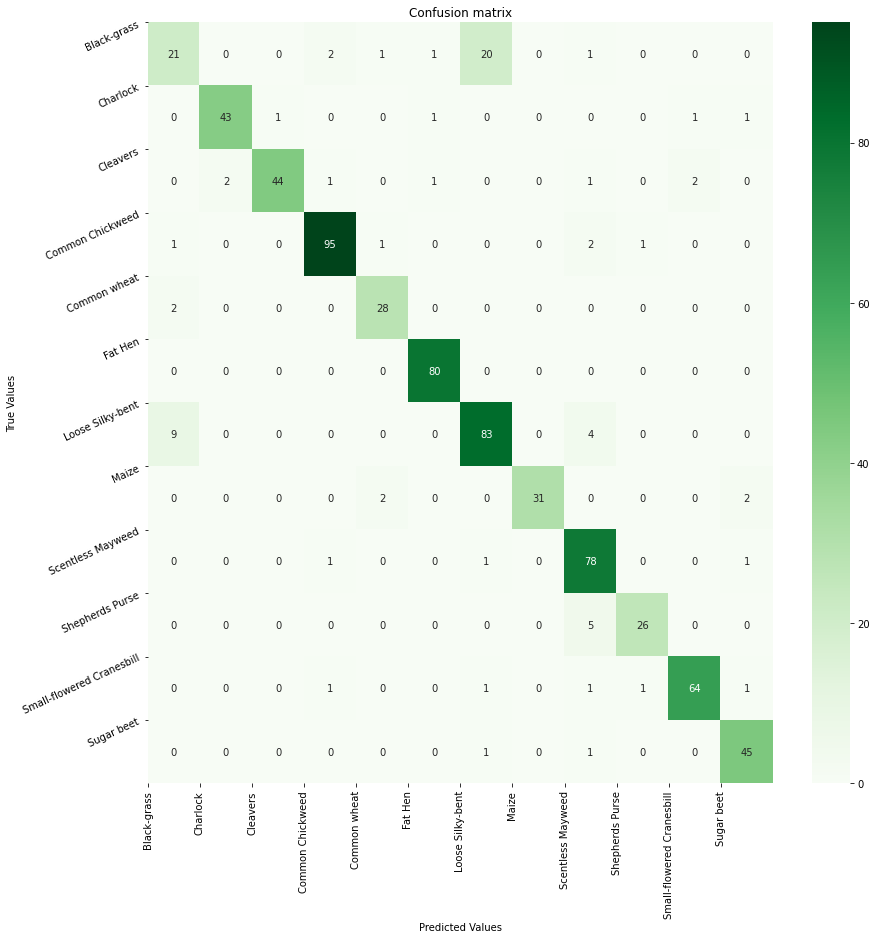

```
Classification Report
                           precision    recall  f1-score   support

              Black-grass       0.64      0.46      0.53        46
                 Charlock       0.96      0.91      0.93        47
                 Cleavers       0.98      0.86      0.92        51
         Common Chickweed       0.95      0.95      0.95       100
             Common wheat       0.88      0.93      0.90        30
                  Fat Hen       0.96      1.00      0.98        80
         Loose Silky-bent       0.78      0.86      0.82        96
                    Maize       1.00      0.89      0.94        35
        Scentless Mayweed       0.84      0.96      0.90        81
          Shepherds Purse       0.93      0.84      0.88        31
Small-flowered Cranesbill       0.96      0.93      0.94        69
               Sugar beet       0.90      0.96      0.93        47

                 accuracy                           0.89       713
                macro avg       0.90      0.88      0.89       713
             weighted avg       0.89      0.89      0.89       713
```

```python
from sklearn import metrics
from sklearn.metrics import classification_report
from sklearn.metrics import confusion_matrix, recall_score, precision_score, f1_score, roc_auc_score,accuracy_score

# Predict the values from the validation dataset
Y_pred = model.predict(X_val)
# Convert predictions classes to one hot vectors
Y_pred_classes = np.argmax(Y_pred,axis = 1)
# Convert validation observations to one hot vectors
Y_true = np.argmax(Y_val,axis = 1)

# Compute the confusion matrix
conf_mtx = confusion_matrix(Y_true, Y_pred_classes)
print("------ Confusion Matrix ------")
print(conf_mtx)

# Plot Confusion matrix
plt.figure(figsize=(14,14))
sns.heatmap(conf_mtx, cmap=plt.cm.Greens, annot=True)
plt.title('Confusion matrix')
plt.ylabel('True Values')
plt.xlabel('Predicted Values')
tick_marks = np.arange(len(enc.classes_))
plt.xticks(tick_marks, enc.classes_, rotation=90)
plt.yticks(tick_marks, enc.classes_, rotation=25)
plt.show();

# Print Classification Report
print('Classification Report')
print(classification_report(Y_true,Y_pred_classes,target_names=enc.classes_))
```

```python
X_test.shape
```

```
(712, 128, 128, 3)
```

```python
y_test.shape
```

```
(712, 12)
```

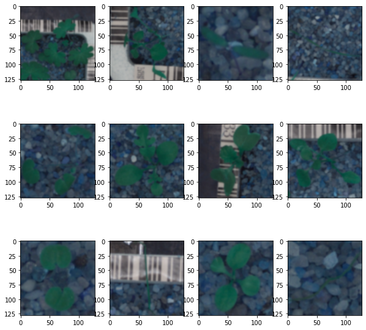

```python
y_pred = model.predict(X_test)
predict_class = np.argmax(y_pred, axis=1)
true_class = np.argmax(y_test,axis=1)

plt.figure(figsize=(10,10))
for i in range(12):
    plt.subplot(3,4,i+1)
    plt.imshow(X_test[i])
```

```python
predict_class
```

```
array([ 9,  3,  5,  0, 10,  9,  1,  3, 10,  6,  9,  6,  6,  8,  6,  7,  6,
        3,  8,  3,  6,  6,  0, 11,  5, 11,  0,  2,  4,  8,  7,  6,  9,  0,
        6,  5, 10,  1,  0, 11,  8,  6,  8,  3,  2, 11, 10, 11,  2,  8,  8,
       10,  3,  3, 10, 10,  1,  1,  3,  5,  5, 10, 11,  4,  1, 10,  3, 11,
        2,  8, 11,  5,  2,  1,  2,  3,  1,  8,  3,  3,  6, 11,  7,  6,  3,
       11,  8,  3, 10,  6,  9,  2,  5, 10,  2,  8,  8,  6, 11,  0,  1,  8,
        8,  1,  9,  6, 10,  9, 10,  7,  8,  9,  8,  6,  3,  5,  6,  8,  5,
        5,  3,  3,  6,  6,  8, 11,  0, 11, 10, 10,  5,  5,  6,  7,  9,  1,
        3,  9, 10,  6,  3,  8,  1,  5, 10,  5,  7,  4,  2,  6,  2, 11,  3,
        8,  6,  6,  3,  5,  1, 10,  4,  1,  9,  3,  5,  5,  8,  1,  0, 10,
        2, 11,  6,  5,  0,  1,  0,  2,  0, 10,  9,  8,  4,  6,  5,  6,  6,
        8, 11,  1, 10,  6,  4,  3,  8,  7,  8,  3,  3,  6,  2,  0,  5,  4,
        6, 10,  3,  6,  6,  6,  7,  7,  8,  6,  3,  3,  7,  2, 11,  3,  6,
        3, 11, 10,  5, 10,  3,  9,  1,  8, 11,  5,  6,  5,  4,  6,  2,  6,
       10, 11,  6, 10,  8,  9, 10, 10,  5,  5,  8, 10,  2, 10,  1,  1,  4,
```

[output cut: 27 more lines]

```python
true_class
```

```
array([10,  3,  5,  0, 10,  9,  1,  3, 10,  6,  9,  6,  6,  9,  6,  7,  0,
        3,  8,  3,  6,  6,  0, 11,  5, 11,  0,  2,  4,  8,  7,  6,  9,  0,
        0,  5, 10,  2,  6, 11,  8,  0,  8,  3,  2, 11, 10, 11,  2,  8,  8,
       10,  3,  3, 10, 10,  1,  1,  3,  5,  5, 10, 11,  4,  1, 10,  3, 11,
        2,  8, 11,  5,  2,  1,  2,  3,  1,  8,  3,  3,  6, 11,  7,  0,  3,
       11,  8,  3, 10,  6,  9,  2,  5, 10,  1,  8,  8,  6, 11,  0,  1,  8,
        6,  2,  9,  6, 10,  9, 10,  7,  8,  9,  8,  6,  3,  5,  6,  8,  5,
        5,  3,  3,  6,  6,  8, 11,  0, 11,  1, 10,  5,  5,  6,  7,  3,  1,
        3,  8,  2,  6,  3,  8,  1,  5, 10,  5,  7, 11,  2,  6,  2, 11,  3,
        8,  0,  6,  3,  5,  1, 10,  4,  1,  9,  3,  5,  5,  8, 10,  0,  2,
        2, 11,  6,  5,  0,  1,  6,  2,  0, 10,  9,  8,  4,  6,  5,  6,  6,
        8, 11,  1, 10,  6,  4,  3,  8,  7,  6,  3,  3,  6,  2,  0,  5,  4,
        6, 10,  3,  6,  6,  6,  7,  7,  8,  0,  3,  3,  7,  2, 11,  3,  6,
        3, 11, 10,  5, 10,  3,  9,  1,  8, 11,  5,  6,  5,  4,  6,  2,  0,
       10, 11,  6, 10,  8,  9, 10, 10,  5,  5,  8, 10,  2, 10,  1,  1,  4,
```

[output cut: 27 more lines]

```python
enc.classes_
```

```
array(['Black-grass', 'Charlock', 'Cleavers', 'Common Chickweed',
       'Common wheat', 'Fat Hen', 'Loose Silky-bent', 'Maize',
       'Scentless Mayweed', 'Shepherds Purse',
       'Small-flowered Cranesbill', 'Sugar beet'], dtype='<U25')
```

### Visualize predictions

```python
from sklearn import preprocessing

def display_predictions(img_array, index,y_pred,y_test):
        img = img_array[index]
        plt.imshow(img)
        plt.show();
        predict_class = np.argmax(y_pred,axis=1)
        true_class = np.argmax(y_test,axis=1)
        print("Predicted Class Index:" ,predict_class[index])
        print("Predicted Class Label:" ,enc.classes_[predict_class[index]])
        print("True Class Index:" ,true_class[index])
        print("True Class Label:" ,enc.classes_[true_class[index]])
```

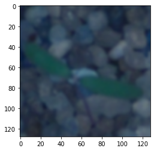

```
Predicted Class Index: 5
Predicted Class Label: Fat Hen
True Class Index: 5
True Class Label: Fat Hen
```

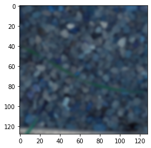

```
Predicted Class Index: 0
Predicted Class Label: Black-grass
True Class Index: 0
True Class Label: Black-grass
```

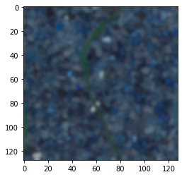

```
Predicted Class Index: 0
Predicted Class Label: Black-grass
True Class Index: 0
True Class Label: Black-grass
```

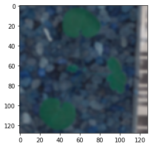

```
Predicted Class Index: 10
Predicted Class Label: Small-flowered Cranesbill
True Class Index: 10
True Class Label: Small-flowered Cranesbill
```

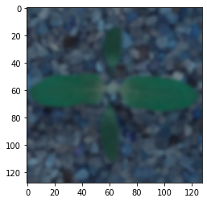

```
Predicted Class Index: 5
Predicted Class Label: Fat Hen
True Class Index: 5
True Class Label: Fat Hen
```

```python
# Visualize predictions for x_test[2], x_test[3], x_test[33], x_test[36], x_test[59]

display_predictions(X_test,2,y_pred,y_test)
display_predictions(X_test,3,y_pred,y_test)
display_predictions(X_test,33,y_pred,y_test)
display_predictions(X_test,36,y_pred,y_test)
display_predictions(X_test,59,y_pred,y_test)
```

```python
model.load_weights('best_model.h5')
```